# Visualisation des évolutions

# 1 Introduction

Dans la partie précédente, on a vu des graphiques pour comparer des variables. Dans cette partie, on a créer des graphiques pour visualiser l’évolution des variables au cours du temps.

# 2 Evolution départements

Pour visualiser une évolution, le plus classique est le graphique à lignes.

- On va choisir les 6 plus grands départements en termes de nombre d’accidents.
- L’idée sera de visualiser l’évolution du nombre d’accident selon les différentes années.
- Et on pourra ainsi les comparer entre eux.

## 2.1 Transformation des données

Dans un premier temps, on va créer une série de données dont les variables sont: département, année, nombre d’accidents.

- On va d’abord sélectionner les départements suivants: `c("750","130","920","930","940","690")` (on peut enlever le zéro).
- Ensuite, on doit créer une data.table qui permet de compter le nombre d’accidents dans ces départements, en fonction des années.

## 2.2 Création du graphique

On va utiliser `geom_line` pour créer un graphique à ligne.

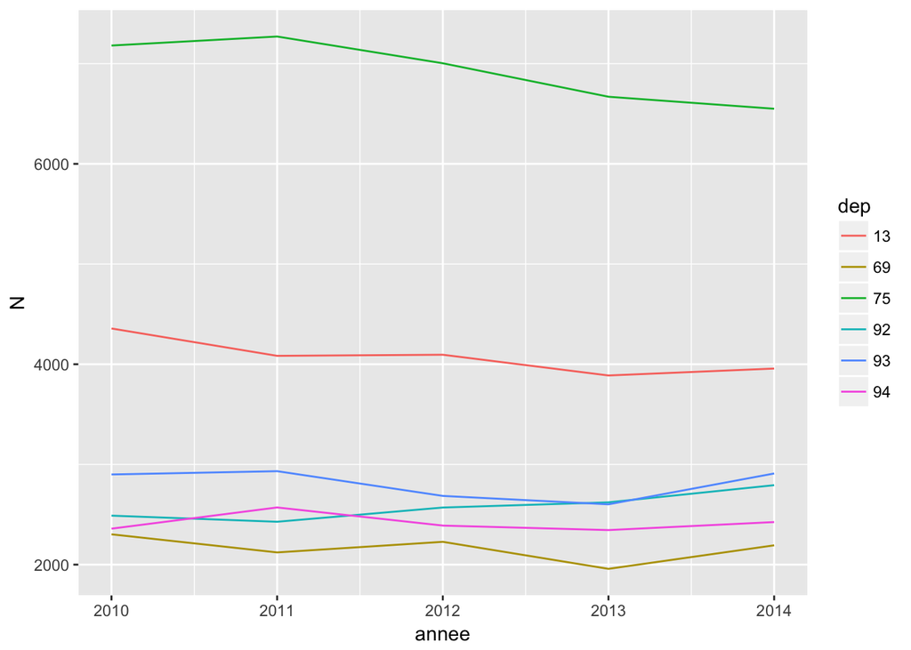

Afin d’optimiser la lecture, on peut placer la légende juste à côté des lignes.

- On va afficher afficher les textes au bout de chaque ligne
- Il est nécessaire de décaler la limite de l’axe x pour avoir de la place
- Il faut aussi enlever la légende originale.

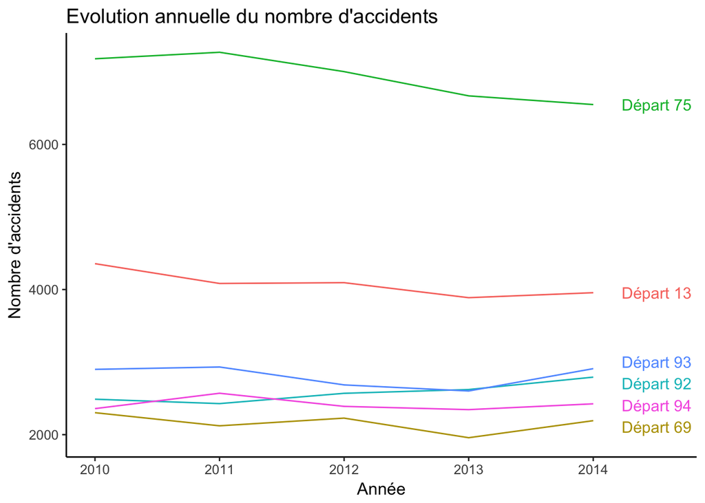

# 3 Graphique interactif

Pour pouvoir lire toutes les valeurs, et zoomer, un graphique interactif peut aider. Ce type de graphiques est souvent utilisé pour les séries temporelles, comme le cours d’une action.

- Créer une série temporelle à l’aide de xts
- Créer le graphique avec dygraphs
- Le nombre affiché est le nombre moyen par jour (sur une période de 7 jours par défaut, il est possible de mettre à jour le paramètre)

[interactive chart not shown]

# 4 Visualisation des périodicités

## 4.1 Mois

- On peut visualiser le nombre en fonction des 12 mois de l’année

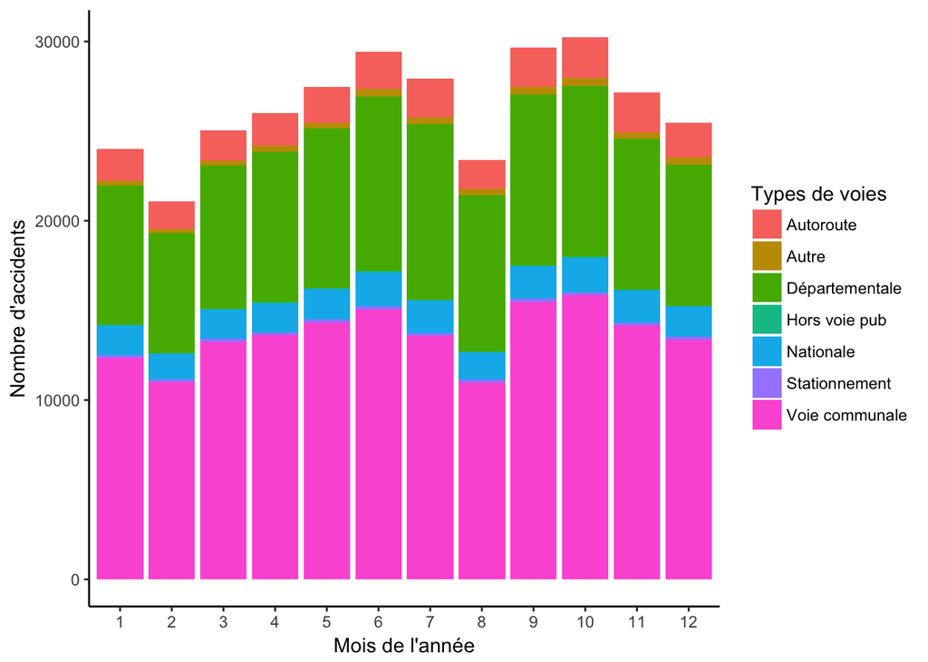

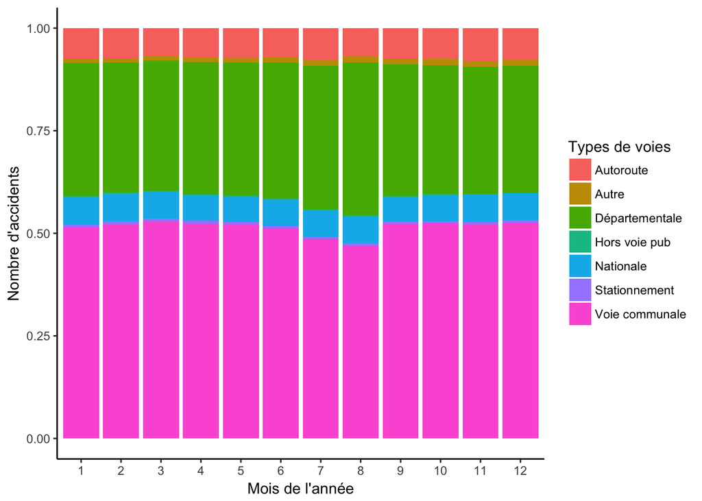

## 4.2 Semaines

- On fait de même pour les jours de la semaine

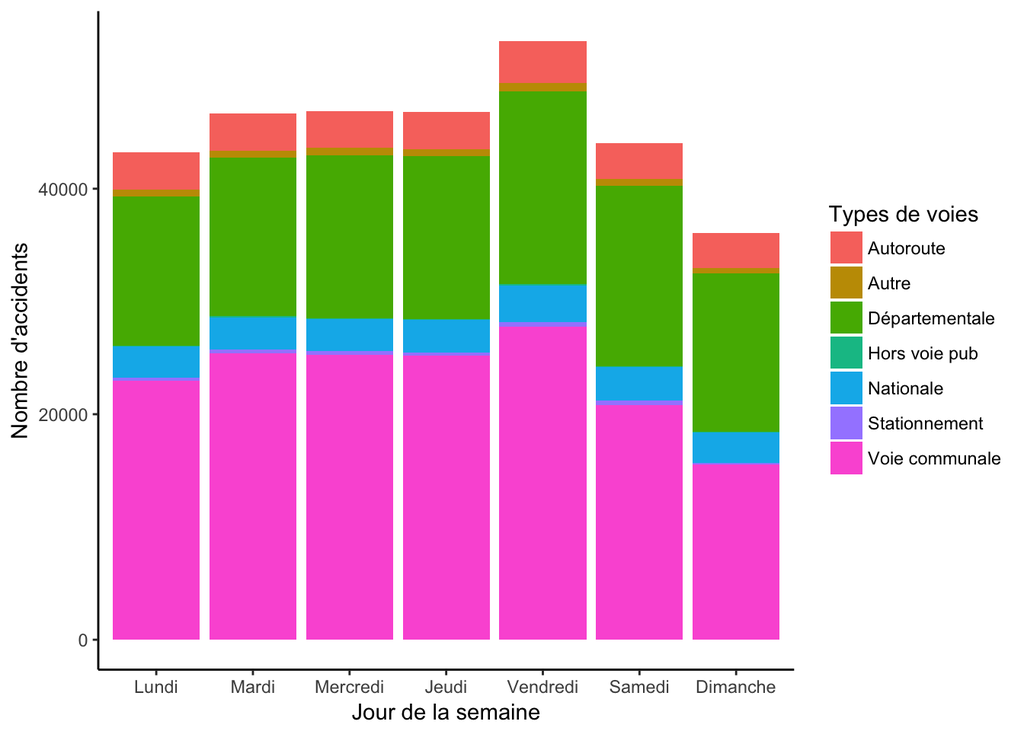

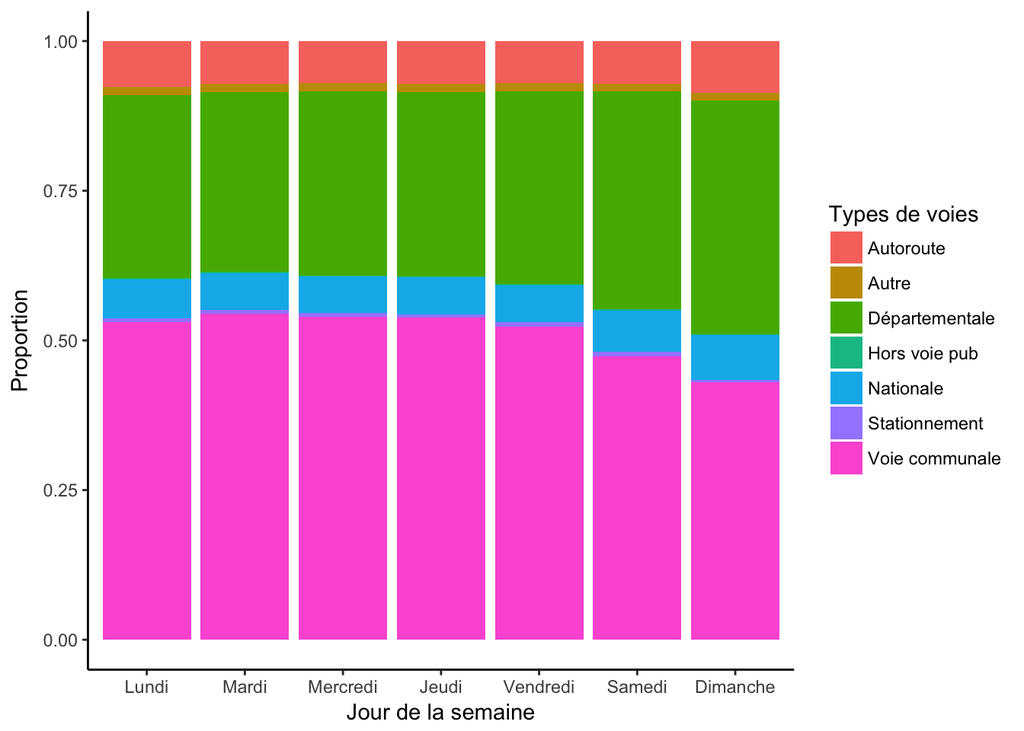

## 4.3 Heures

- On peut également visualiser les évolutions au cours d’une journée.

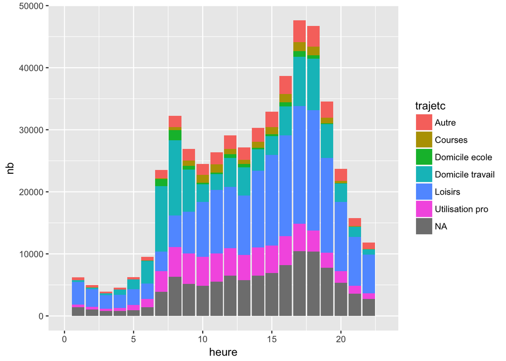

On peut voir le graphique en fonction des jours de la semaine.

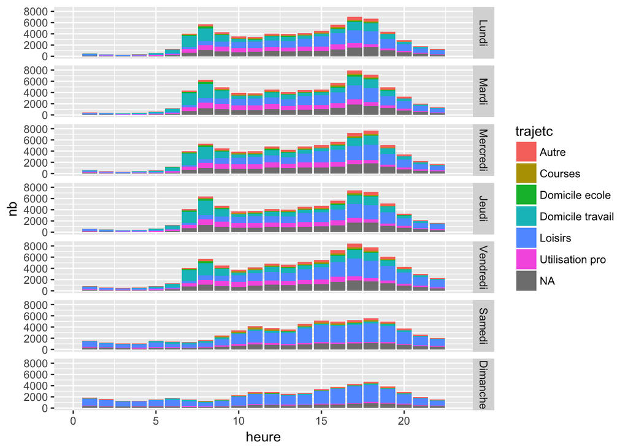

# 5 Grahique circulaire

- Afin de représenter la saisonnalité de l’évolution, on peut créer un graphique circulaire.

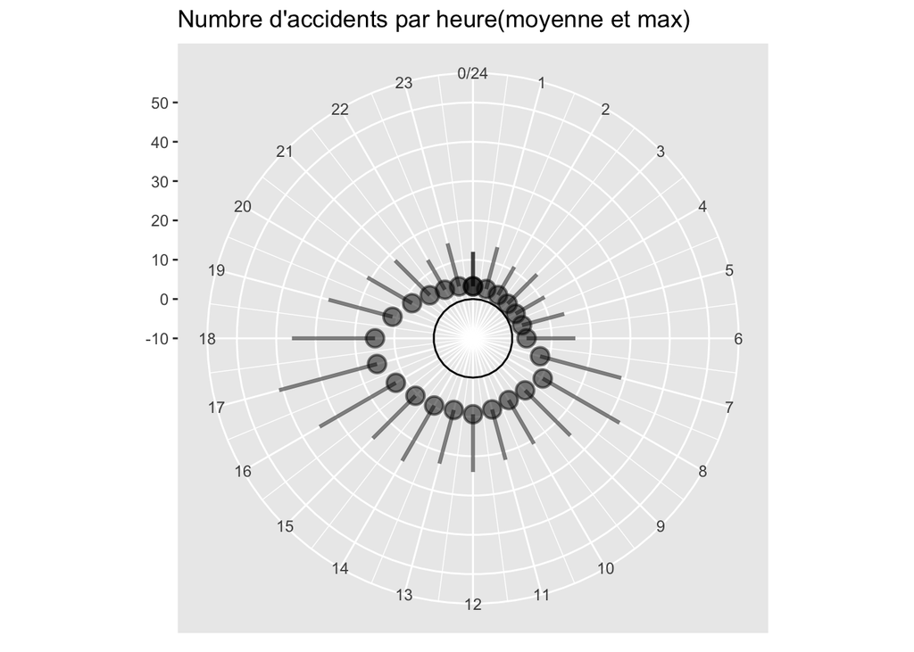

```
##
##    Lundi    Mardi Mercredi    Jeudi Vendredi   Samedi Dimanche
##       25       25       25       25       25       25       25
```

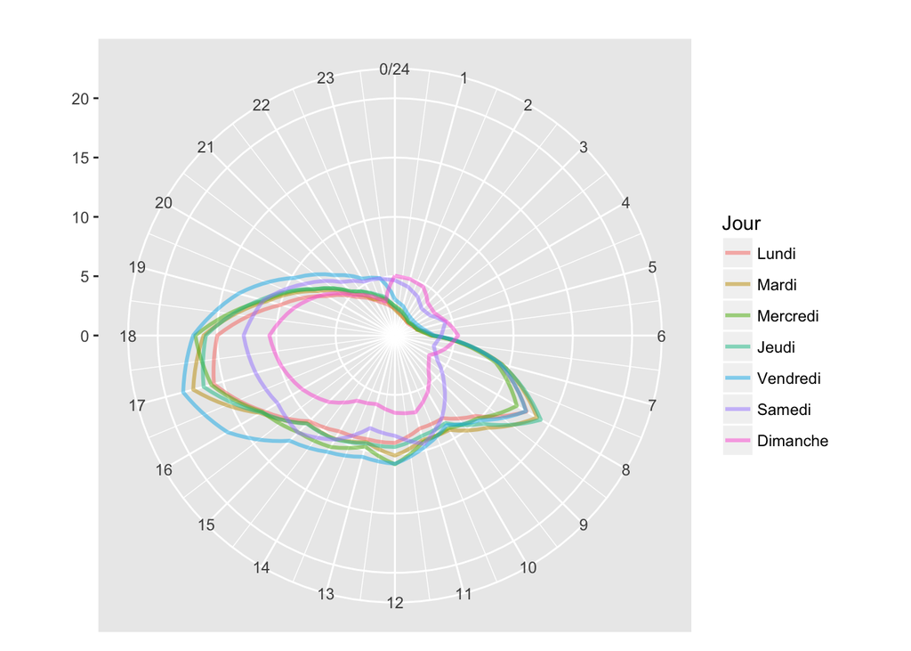

Copyright © 2017 Blog de Kezhan Shi